# Risk Factor Analysis

## Outcome Variable

**Outcome Variable:** sstunted

## Predictor Variables

**Intervention Variable:** mwtkg

**Adjustment Set:**

- arm
- W_mage
- meducyrs
- feducyrs
- single
- brthmon
- W_parity
- delta_W_mage
- delta_meducyrs
- delta_feducyrs
- delta_single
- delta_brthmon
- delta_W_parity

## Stratifying Variables

The analysis was stratified on these variable(s):

- agecat
- studyid
- country

## Data Summary

| agecat | studyid | country | mwtkg | sstunted | n_cell | n |
| --- | --- | --- | --- | --- | --- | --- |
| Birth | JiVitA-3 | BANGLADESH | >=58 kg | 0 | 456 | 22432 |
| Birth | JiVitA-3 | BANGLADESH | >=58 kg | 1 | 44 | 22432 |
| Birth | JiVitA-3 | BANGLADESH | <52 kg | 0 | 18204 | 22432 |
| Birth | JiVitA-3 | BANGLADESH | <52 kg | 1 | 2275 | 22432 |
| Birth | JiVitA-3 | BANGLADESH | [52-58) kg | 0 | 1325 | 22432 |
| Birth | JiVitA-3 | BANGLADESH | [52-58) kg | 1 | 128 | 22432 |
| Birth | MAL-ED | BANGLADESH | >=58 kg | 0 | 38 | 222 |
| Birth | MAL-ED | BANGLADESH | >=58 kg | 1 | 0 | 222 |
| Birth | MAL-ED | BANGLADESH | <52 kg | 0 | 136 | 222 |
| Birth | MAL-ED | BANGLADESH | <52 kg | 1 | 7 | 222 |
| Birth | MAL-ED | BANGLADESH | [52-58) kg | 0 | 41 | 222 |
| Birth | MAL-ED | BANGLADESH | [52-58) kg | 1 | 0 | 222 |
| Birth | MAL-ED | BRAZIL | >=58 kg | 0 | 32 | 64 |
| Birth | MAL-ED | BRAZIL | >=58 kg | 1 | 2 | 64 |
| Birth | MAL-ED | BRAZIL | <52 kg | 0 | 15 | 64 |
| Birth | MAL-ED | BRAZIL | <52 kg | 1 | 0 | 64 |
| Birth | MAL-ED | BRAZIL | [52-58) kg | 0 | 14 | 64 |
| Birth | MAL-ED | BRAZIL | [52-58) kg | 1 | 1 | 64 |
| Birth | MAL-ED | INDIA | >=58 kg | 0 | 6 | 43 |
| Birth | MAL-ED | INDIA | >=58 kg | 1 | 0 | 43 |
| Birth | MAL-ED | INDIA | <52 kg | 0 | 28 | 43 |
| Birth | MAL-ED | INDIA | <52 kg | 1 | 1 | 43 |
| Birth | MAL-ED | INDIA | [52-58) kg | 0 | 7 | 43 |
| Birth | MAL-ED | INDIA | [52-58) kg | 1 | 1 | 43 |
| Birth | MAL-ED | NEPAL | >=58 kg | 0 | 9 | 27 |
| Birth | MAL-ED | NEPAL | >=58 kg | 1 | 0 | 27 |
| Birth | MAL-ED | NEPAL | <52 kg | 0 | 7 | 27 |
| Birth | MAL-ED | NEPAL | <52 kg | 1 | 1 | 27 |
| Birth | MAL-ED | NEPAL | [52-58) kg | 0 | 10 | 27 |
| Birth | MAL-ED | NEPAL | [52-58) kg | 1 | 0 | 27 |

[output cut: 240 more lines]

The following strata were considered:

- agecat: 24 months, studyid: JiVitA-3, country: BANGLADESH
- agecat: 24 months, studyid: LCNI-5, country: MALAWI
- agecat: 24 months, studyid: MAL-ED, country: BANGLADESH
- agecat: 24 months, studyid: MAL-ED, country: BRAZIL
- agecat: 24 months, studyid: MAL-ED, country: INDIA
- agecat: 24 months, studyid: MAL-ED, country: NEPAL
- agecat: 24 months, studyid: MAL-ED, country: PERU
- agecat: 24 months, studyid: MAL-ED, country: SOUTH AFRICA
- agecat: 24 months, studyid: MAL-ED, country: TANZANIA, UNITED REPUBLIC OF
- agecat: 24 months, studyid: NIH-Birth, country: BANGLADESH
- agecat: 24 months, studyid: NIH-Crypto, country: BANGLADESH
- agecat: 24 months, studyid: PROBIT, country: BELARUS
- agecat: 24 months, studyid: PROVIDE, country: BANGLADESH
- agecat: 24 months, studyid: TanzaniaChild2, country: TANZANIA, UNITED REPUBLIC OF
- agecat: 24 months, studyid: ZVITAMBO, country: ZIMBABWE
- agecat: 6 months, studyid: JiVitA-3, country: BANGLADESH
- agecat: 6 months, studyid: LCNI-5, country: MALAWI
- agecat: 6 months, studyid: MAL-ED, country: BANGLADESH
- agecat: 6 months, studyid: MAL-ED, country: BRAZIL
- agecat: 6 months, studyid: MAL-ED, country: INDIA
- agecat: 6 months, studyid: MAL-ED, country: NEPAL
- agecat: 6 months, studyid: MAL-ED, country: PERU
- agecat: 6 months, studyid: MAL-ED, country: SOUTH AFRICA
- agecat: 6 months, studyid: MAL-ED, country: TANZANIA, UNITED REPUBLIC OF
- agecat: 6 months, studyid: NIH-Birth, country: BANGLADESH
- agecat: 6 months, studyid: NIH-Crypto, country: BANGLADESH
- agecat: 6 months, studyid: PROBIT, country: BELARUS
- agecat: 6 months, studyid: PROVIDE, country: BANGLADESH
- agecat: 6 months, studyid: SAS-CompFeed, country: INDIA
- agecat: 6 months, studyid: TanzaniaChild2, country: TANZANIA, UNITED REPUBLIC OF
- agecat: 6 months, studyid: ZVITAMBO, country: ZIMBABWE
- agecat: Birth, studyid: JiVitA-3, country: BANGLADESH
- agecat: Birth, studyid: MAL-ED, country: BANGLADESH
- agecat: Birth, studyid: MAL-ED, country: BRAZIL
- agecat: Birth, studyid: MAL-ED, country: INDIA
- agecat: Birth, studyid: MAL-ED, country: NEPAL
- agecat: Birth, studyid: MAL-ED, country: PERU
- agecat: Birth, studyid: MAL-ED, country: SOUTH AFRICA
- agecat: Birth, studyid: MAL-ED, country: TANZANIA, UNITED REPUBLIC OF
- agecat: Birth, studyid: NIH-Birth, country: BANGLADESH
- agecat: Birth, studyid: NIH-Crypto, country: BANGLADESH
- agecat: Birth, studyid: PROBIT, country: BELARUS
- agecat: Birth, studyid: PROVIDE, country: BANGLADESH
- agecat: Birth, studyid: SAS-CompFeed, country: INDIA
- agecat: Birth, studyid: ZVITAMBO, country: ZIMBABWE

### Dropped Strata

Some strata were dropped due to rare outcomes:

- agecat: Birth, studyid: MAL-ED, country: BANGLADESH
- agecat: Birth, studyid: MAL-ED, country: BRAZIL
- agecat: Birth, studyid: MAL-ED, country: INDIA
- agecat: Birth, studyid: MAL-ED, country: NEPAL
- agecat: Birth, studyid: MAL-ED, country: PERU
- agecat: Birth, studyid: MAL-ED, country: SOUTH AFRICA
- agecat: Birth, studyid: MAL-ED, country: TANZANIA, UNITED REPUBLIC OF
- agecat: Birth, studyid: NIH-Birth, country: BANGLADESH
- agecat: Birth, studyid: NIH-Crypto, country: BANGLADESH
- agecat: Birth, studyid: PROBIT, country: BELARUS
- agecat: Birth, studyid: PROVIDE, country: BANGLADESH
- agecat: Birth, studyid: SAS-CompFeed, country: INDIA
- agecat: 6 months, studyid: MAL-ED, country: BANGLADESH
- agecat: 6 months, studyid: MAL-ED, country: BRAZIL
- agecat: 6 months, studyid: MAL-ED, country: INDIA
- agecat: 6 months, studyid: MAL-ED, country: NEPAL
- agecat: 6 months, studyid: MAL-ED, country: PERU
- agecat: 6 months, studyid: MAL-ED, country: SOUTH AFRICA
- agecat: 6 months, studyid: MAL-ED, country: TANZANIA, UNITED REPUBLIC OF
- agecat: 6 months, studyid: NIH-Birth, country: BANGLADESH
- agecat: 6 months, studyid: NIH-Crypto, country: BANGLADESH
- agecat: 6 months, studyid: PROVIDE, country: BANGLADESH
- agecat: 6 months, studyid: SAS-CompFeed, country: INDIA
- agecat: 6 months, studyid: TanzaniaChild2, country: TANZANIA, UNITED REPUBLIC OF
- agecat: 24 months, studyid: LCNI-5, country: MALAWI
- agecat: 24 months, studyid: MAL-ED, country: BANGLADESH
- agecat: 24 months, studyid: MAL-ED, country: BRAZIL
- agecat: 24 months, studyid: MAL-ED, country: INDIA
- agecat: 24 months, studyid: MAL-ED, country: NEPAL
- agecat: 24 months, studyid: MAL-ED, country: PERU
- agecat: 24 months, studyid: NIH-Crypto, country: BANGLADESH
- agecat: 24 months, studyid: PROVIDE, country: BANGLADESH
- agecat: 24 months, studyid: TanzaniaChild2, country: TANZANIA, UNITED REPUBLIC OF

## Methods Detail

We’re interested in the causal parameters $E[Y_a]$ for all values of $a \in \mathcal{A}$. These parameters represent the mean outcome if, possibly contrary to fact, we intervened to set all units to have $A=a$. Under the randomization and positivity assumptions, these are identified by the statistical parameters $\psi_a=E_W[E_{Y|A,W}(Y|A=a,W)]$. In addition, we’re interested in the mean of $Y$, $E[Y]$ under no intervention (the observed mean). We will estimate these parameters by using SuperLearner to fit the relevant likelihood factors – $E_{Y|A,W}(Y|A=a,W)$ and $p(A=a|W)$, and then updating our likelihood fit using a joint TMLE.

For unadjusted analyses ($W=\{\}$), initial likelihoods were estimated using Lrnr_glm to estimate the simple $E(Y|A)$ and Lrnr_mean to estimate $p(A)$. For adjusted analyses, a small library containing Lrnr_glmnet, Lrnr_xgboost, and Lrnr_mean was used.

Having estimated these parameters, we will then use the delta method to estimate relative risks and attributable risks relative to a prespecified baseline level of $A$.

# Results Detail

## Results Plots

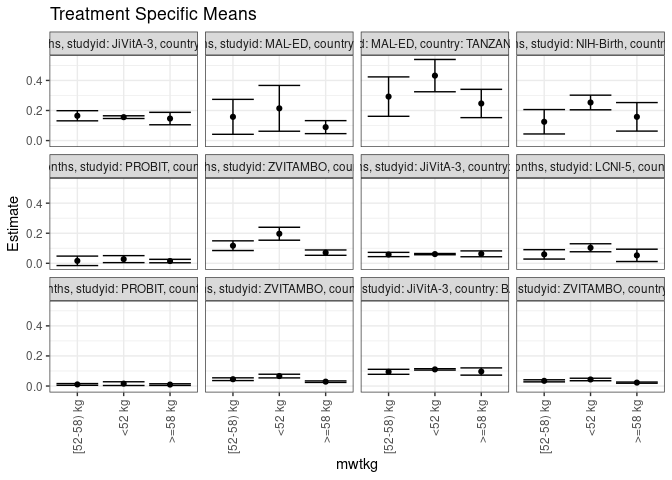

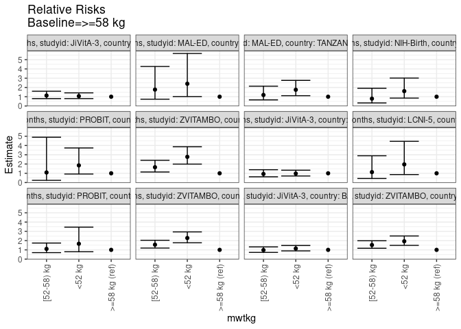

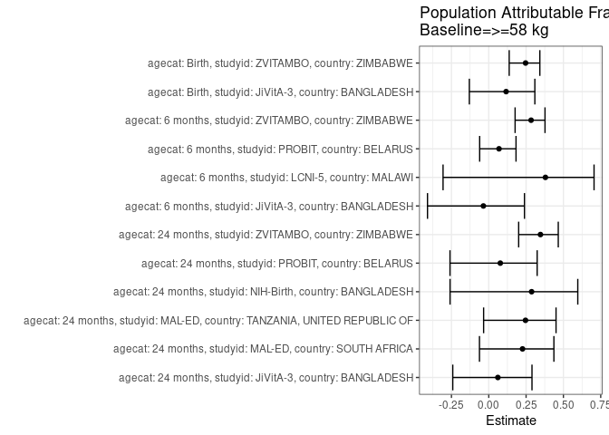

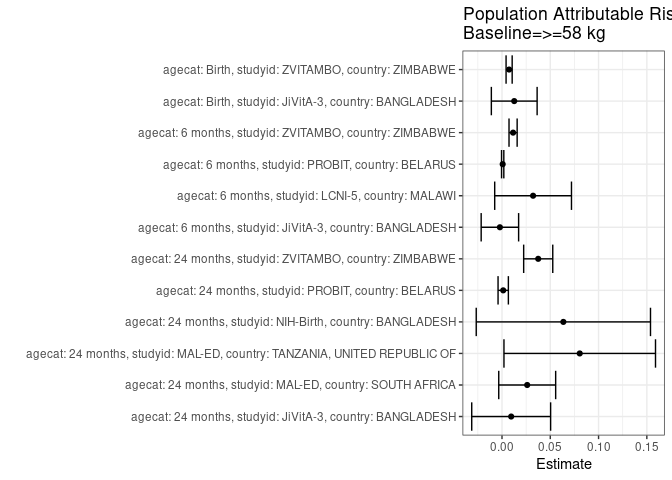

## Results Table

### Parameter: TSM

| agecat | studyid | country | intervention_level | baseline_level | estimate | ci_lower | ci_upper |
| --- | --- | --- | --- | --- | --- | --- | --- |
| Birth | JiVitA-3 | BANGLADESH | >=58 kg | NA | 0.0964176 | 0.0723652 | 0.1204700 |
| Birth | JiVitA-3 | BANGLADESH | <52 kg | NA | 0.1104816 | 0.1057885 | 0.1151747 |
| Birth | JiVitA-3 | BANGLADESH | [52-58) kg | NA | 0.0944298 | 0.0777558 | 0.1111037 |
| Birth | ZVITAMBO | ZIMBABWE | >=58 kg | NA | 0.0225421 | 0.0186416 | 0.0264425 |
| Birth | ZVITAMBO | ZIMBABWE | <52 kg | NA | 0.0434385 | 0.0350523 | 0.0518247 |
| Birth | ZVITAMBO | ZIMBABWE | [52-58) kg | NA | 0.0344172 | 0.0275916 | 0.0412428 |
| 6 months | JiVitA-3 | BANGLADESH | >=58 kg | NA | 0.0628919 | 0.0435055 | 0.0822784 |
| 6 months | JiVitA-3 | BANGLADESH | <52 kg | NA | 0.0610900 | 0.0569890 | 0.0651910 |
| 6 months | JiVitA-3 | BANGLADESH | [52-58) kg | NA | 0.0583558 | 0.0441593 | 0.0725522 |
| 6 months | LCNI-5 | MALAWI | >=58 kg | NA | 0.0526316 | 0.0116170 | 0.0936461 |
| 6 months | LCNI-5 | MALAWI | <52 kg | NA | 0.1031746 | 0.0766021 | 0.1297471 |
| 6 months | LCNI-5 | MALAWI | [52-58) kg | NA | 0.0593607 | 0.0280461 | 0.0906753 |
| 6 months | PROBIT | BELARUS | >=58 kg | NA | 0.0095510 | 0.0041176 | 0.0149844 |
| 6 months | PROBIT | BELARUS | <52 kg | NA | 0.0158325 | 0.0035071 | 0.0281580 |
| 6 months | PROBIT | BELARUS | [52-58) kg | NA | 0.0105522 | 0.0048782 | 0.0162262 |
| 6 months | ZVITAMBO | ZIMBABWE | >=58 kg | NA | 0.0289918 | 0.0239149 | 0.0340686 |
| 6 months | ZVITAMBO | ZIMBABWE | <52 kg | NA | 0.0660716 | 0.0539597 | 0.0781836 |
| 6 months | ZVITAMBO | ZIMBABWE | [52-58) kg | NA | 0.0452014 | 0.0361038 | 0.0542990 |
| 24 months | JiVitA-3 | BANGLADESH | >=58 kg | NA | 0.1464088 | 0.1049967 | 0.1878210 |
| 24 months | JiVitA-3 | BANGLADESH | <52 kg | NA | 0.1557115 | 0.1466677 | 0.1647553 |
| 24 months | JiVitA-3 | BANGLADESH | [52-58) kg | NA | 0.1649548 | 0.1311921 | 0.1987175 |
| 24 months | MAL-ED | SOUTH AFRICA | >=58 kg | NA | 0.0892857 | 0.0460736 | 0.1324978 |
| 24 months | MAL-ED | SOUTH AFRICA | <52 kg | NA | 0.2142857 | 0.0619759 | 0.3665956 |
| 24 months | MAL-ED | SOUTH AFRICA | [52-58) kg | NA | 0.1578947 | 0.0417089 | 0.2740806 |
| 24 months | MAL-ED | TANZANIA, UNITED REPUBLIC OF | >=58 kg | NA | 0.2465988 | 0.1524081 | 0.3407895 |
| 24 months | MAL-ED | TANZANIA, UNITED REPUBLIC OF | <52 kg | NA | 0.4319972 | 0.3246493 | 0.5393450 |
| 24 months | MAL-ED | TANZANIA, UNITED REPUBLIC OF | [52-58) kg | NA | 0.2924503 | 0.1613899 | 0.4235106 |
| 24 months | NIH-Birth | BANGLADESH | >=58 kg | NA | 0.1578947 | 0.0631218 | 0.2526677 |
| 24 months | NIH-Birth | BANGLADESH | <52 kg | NA | 0.2532468 | 0.2046239 | 0.3018696 |
| 24 months | NIH-Birth | BANGLADESH | [52-58) kg | NA | 0.1250000 | 0.0438808 | 0.2061192 |
| 24 months | PROBIT | BELARUS | >=58 kg | NA | 0.0149452 | 0.0035926 | 0.0262978 |
| 24 months | PROBIT | BELARUS | <52 kg | NA | 0.0276923 | 0.0043761 | 0.0510085 |
| 24 months | PROBIT | BELARUS | [52-58) kg | NA | 0.0162482 | -0.0152062 | 0.0477025 |
| 24 months | ZVITAMBO | ZIMBABWE | >=58 kg | NA | 0.0708095 | 0.0531310 | 0.0884879 |
| 24 months | ZVITAMBO | ZIMBABWE | <52 kg | NA | 0.1964970 | 0.1535015 | 0.2394925 |
| 24 months | ZVITAMBO | ZIMBABWE | [52-58) kg | NA | 0.1171252 | 0.0848848 | 0.1493656 |

### Parameter: E(Y)

| agecat | studyid | country | intervention_level | baseline_level | estimate | ci_lower | ci_upper |
| --- | --- | --- | --- | --- | --- | --- | --- |
| Birth | JiVitA-3 | BANGLADESH | NA | NA | 0.1090852 | 0.1045269 | 0.1136436 |
| Birth | ZVITAMBO | ZIMBABWE | NA | NA | 0.0299157 | 0.0267365 | 0.0330949 |
| 6 months | JiVitA-3 | BANGLADESH | NA | NA | 0.0607071 | 0.0568535 | 0.0645606 |
| 6 months | LCNI-5 | MALAWI | NA | NA | 0.0848268 | 0.0659398 | 0.1037138 |
| 6 months | PROBIT | BELARUS | NA | NA | 0.0102556 | 0.0050084 | 0.0155028 |
| 6 months | ZVITAMBO | ZIMBABWE | NA | NA | 0.0404652 | 0.0362140 | 0.0447164 |
| 24 months | JiVitA-3 | BANGLADESH | NA | NA | 0.1559059 | 0.1471753 | 0.1646364 |
| 24 months | MAL-ED | SOUTH AFRICA | NA | NA | 0.1153846 | 0.0743622 | 0.1564070 |
| 24 months | MAL-ED | TANZANIA, UNITED REPUBLIC OF | NA | NA | 0.3271028 | 0.2640978 | 0.3901078 |
| 24 months | NIH-Birth | BANGLADESH | NA | NA | 0.2214452 | 0.1821080 | 0.2607825 |
| 24 months | PROBIT | BELARUS | NA | NA | 0.0161974 | 0.0018682 | 0.0305265 |
| 24 months | ZVITAMBO | ZIMBABWE | NA | NA | 0.1083123 | 0.0930224 | 0.1236023 |

### Parameter: RR

| agecat | studyid | country | intervention_level | baseline_level | estimate | ci_lower | ci_upper |
| --- | --- | --- | --- | --- | --- | --- | --- |
| Birth | JiVitA-3 | BANGLADESH | >=58 kg | >=58 kg | 1.0000000 | 1.0000000 | 1.000000 |
| Birth | JiVitA-3 | BANGLADESH | <52 kg | >=58 kg | 1.1458657 | 0.8905754 | 1.474337 |
| Birth | JiVitA-3 | BANGLADESH | [52-58) kg | >=58 kg | 0.9793833 | 0.7257394 | 1.321675 |
| Birth | ZVITAMBO | ZIMBABWE | >=58 kg | >=58 kg | 1.0000000 | 1.0000000 | 1.000000 |
| Birth | ZVITAMBO | ZIMBABWE | <52 kg | >=58 kg | 1.9269954 | 1.4870109 | 2.497165 |
| Birth | ZVITAMBO | ZIMBABWE | [52-58) kg | >=58 kg | 1.5267968 | 1.1737095 | 1.986104 |
| 6 months | JiVitA-3 | BANGLADESH | >=58 kg | >=58 kg | 1.0000000 | 1.0000000 | 1.000000 |
| 6 months | JiVitA-3 | BANGLADESH | <52 kg | >=58 kg | 0.9713490 | 0.7073955 | 1.333793 |
| 6 months | JiVitA-3 | BANGLADESH | [52-58) kg | >=58 kg | 0.9278736 | 0.6223940 | 1.383287 |
| 6 months | LCNI-5 | MALAWI | >=58 kg | >=58 kg | 1.0000000 | 1.0000000 | 1.000000 |
| 6 months | LCNI-5 | MALAWI | <52 kg | >=58 kg | 1.9603175 | 0.8627530 | 4.454166 |
| 6 months | LCNI-5 | MALAWI | [52-58) kg | >=58 kg | 1.1278539 | 0.4401123 | 2.890295 |
| 6 months | PROBIT | BELARUS | >=58 kg | >=58 kg | 1.0000000 | 1.0000000 | 1.000000 |
| 6 months | PROBIT | BELARUS | <52 kg | >=58 kg | 1.6576870 | 0.7957837 | 3.453107 |
| 6 months | PROBIT | BELARUS | [52-58) kg | >=58 kg | 1.1048300 | 0.7030804 | 1.736145 |
| 6 months | ZVITAMBO | ZIMBABWE | >=58 kg | >=58 kg | 1.0000000 | 1.0000000 | 1.000000 |
| 6 months | ZVITAMBO | ZIMBABWE | <52 kg | >=58 kg | 2.2789800 | 1.7687919 | 2.936326 |
| 6 months | ZVITAMBO | ZIMBABWE | [52-58) kg | >=58 kg | 1.5591112 | 1.1941467 | 2.035619 |
| 24 months | JiVitA-3 | BANGLADESH | >=58 kg | >=58 kg | 1.0000000 | 1.0000000 | 1.000000 |
| 24 months | JiVitA-3 | BANGLADESH | <52 kg | >=58 kg | 1.0635390 | 0.7986783 | 1.416234 |
| 24 months | JiVitA-3 | BANGLADESH | [52-58) kg | >=58 kg | 1.1266725 | 0.7964225 | 1.593866 |
| 24 months | MAL-ED | SOUTH AFRICA | >=58 kg | >=58 kg | 1.0000000 | 1.0000000 | 1.000000 |
| 24 months | MAL-ED | SOUTH AFRICA | <52 kg | >=58 kg | 2.4000000 | 1.0156837 | 5.671057 |
| 24 months | MAL-ED | SOUTH AFRICA | [52-58) kg | >=58 kg | 1.7684211 | 0.7329701 | 4.266631 |
| 24 months | MAL-ED | TANZANIA, UNITED REPUBLIC OF | >=58 kg | >=58 kg | 1.0000000 | 1.0000000 | 1.000000 |
| 24 months | MAL-ED | TANZANIA, UNITED REPUBLIC OF | <52 kg | >=58 kg | 1.7518221 | 1.1099568 | 2.764865 |
| 24 months | MAL-ED | TANZANIA, UNITED REPUBLIC OF | [52-58) kg | >=58 kg | 1.1859357 | 0.6575860 | 2.138798 |
| 24 months | NIH-Birth | BANGLADESH | >=58 kg | >=58 kg | 1.0000000 | 1.0000000 | 1.000000 |
| 24 months | NIH-Birth | BANGLADESH | <52 kg | >=58 kg | 1.6038961 | 0.8540608 | 3.012060 |
| 24 months | NIH-Birth | BANGLADESH | [52-58) kg | >=58 kg | 0.7916667 | 0.3270664 | 1.916235 |
| 24 months | PROBIT | BELARUS | >=58 kg | >=58 kg | 1.0000000 | 1.0000000 | 1.000000 |
| 24 months | PROBIT | BELARUS | <52 kg | >=58 kg | 1.8529231 | 0.9193047 | 3.734696 |
| 24 months | PROBIT | BELARUS | [52-58) kg | >=58 kg | 1.0871820 | 0.2415308 | 4.893639 |
| 24 months | ZVITAMBO | ZIMBABWE | >=58 kg | >=58 kg | 1.0000000 | 1.0000000 | 1.000000 |
| 24 months | ZVITAMBO | ZIMBABWE | <52 kg | >=58 kg | 2.7750101 | 1.9909849 | 3.867775 |
| 24 months | ZVITAMBO | ZIMBABWE | [52-58) kg | >=58 kg | 1.6540890 | 1.1404479 | 2.399066 |

### Parameter: PAR

| agecat | studyid | country | intervention_level | baseline_level | estimate | ci_lower | ci_upper |
| --- | --- | --- | --- | --- | --- | --- | --- |
| Birth | JiVitA-3 | BANGLADESH | >=58 kg | NA | 0.0126677 | -0.0110346 | 0.0363699 |
| Birth | ZVITAMBO | ZIMBABWE | >=58 kg | NA | 0.0073736 | 0.0042191 | 0.0105282 |
| 6 months | JiVitA-3 | BANGLADESH | >=58 kg | NA | -0.0021849 | -0.0215765 | 0.0172067 |
| 6 months | LCNI-5 | MALAWI | >=58 kg | NA | 0.0321952 | -0.0075626 | 0.0719530 |
| 6 months | PROBIT | BELARUS | >=58 kg | NA | 0.0007046 | -0.0004695 | 0.0018788 |
| 6 months | ZVITAMBO | ZIMBABWE | >=58 kg | NA | 0.0114735 | 0.0072650 | 0.0156820 |
| 24 months | JiVitA-3 | BANGLADESH | >=58 kg | NA | 0.0094971 | -0.0313589 | 0.0503531 |
| 24 months | MAL-ED | SOUTH AFRICA | >=58 kg | NA | 0.0260989 | -0.0033781 | 0.0555759 |
| 24 months | MAL-ED | TANZANIA, UNITED REPUBLIC OF | >=58 kg | NA | 0.0805040 | 0.0020293 | 0.1589788 |
| 24 months | NIH-Birth | BANGLADESH | >=58 kg | NA | 0.0635505 | -0.0266855 | 0.1537865 |
| 24 months | PROBIT | BELARUS | >=58 kg | NA | 0.0012522 | -0.0040902 | 0.0065945 |
| 24 months | ZVITAMBO | ZIMBABWE | >=58 kg | NA | 0.0375029 | 0.0224401 | 0.0525656 |

### Parameter: PAF

| agecat | studyid | country | intervention_level | baseline_level | estimate | ci_lower | ci_upper |
| --- | --- | --- | --- | --- | --- | --- | --- |
| Birth | JiVitA-3 | BANGLADESH | >=58 kg | NA | 0.1161262 | -0.1301456 | 0.3087325 |
| Birth | ZVITAMBO | ZIMBABWE | >=58 kg | NA | 0.2464799 | 0.1368778 | 0.3421644 |
| 6 months | JiVitA-3 | BANGLADESH | >=58 kg | NA | -0.0359905 | -0.4104654 | 0.2390623 |
| 6 months | LCNI-5 | MALAWI | >=58 kg | NA | 0.3795404 | -0.3062459 | 0.7052851 |
| 6 months | PROBIT | BELARUS | >=58 kg | NA | 0.0687078 | -0.0609771 | 0.1825411 |
| 6 months | ZVITAMBO | ZIMBABWE | >=58 kg | NA | 0.2835390 | 0.1763936 | 0.3767455 |
| 24 months | JiVitA-3 | BANGLADESH | >=58 kg | NA | 0.0609154 | -0.2411930 | 0.2894901 |
| 24 months | MAL-ED | SOUTH AFRICA | >=58 kg | NA | 0.2261905 | -0.0622499 | 0.4363086 |
| 24 months | MAL-ED | TANZANIA, UNITED REPUBLIC OF | >=58 kg | NA | 0.2461123 | -0.0345196 | 0.4506178 |
| 24 months | NIH-Birth | BANGLADESH | >=58 kg | NA | 0.2869806 | -0.2593344 | 0.5962973 |
| 24 months | PROBIT | BELARUS | >=58 kg | NA | 0.0773063 | -0.2597202 | 0.3241645 |
| 24 months | ZVITAMBO | ZIMBABWE | >=58 kg | NA | 0.3462473 | 0.2002897 | 0.4655658 |